# Regressão linear na prática

Hugo Gabriel

## Dados da CAPES sobre avaliação da pós-graduação

A CAPES é um órgão do MEC que tem a atribuição de acompanhar a pós-graduação na universidade brasileira. Uma das formas que ela encontrou de fazer isso e pela qual ela é bastante criticada é através de uma avaliação quantitativa a cada x anos (era 3, mudou para 4).

Usaremos dados da penúltima avaliação da CAPES:

```r
cacc_tudo = read_projectdata()

glimpse(cacc_tudo)
```

```
## Observations: 73
## Variables: 31
## $ Instituição                  <chr> "UNIVERSIDADE FEDERAL DO AMAZONAS...
## $ Programa                     <chr> "INFORMÁTICA (12001015012P2)", "C...
## $ Nível                        <int> 5, 4, 3, 3, 3, 5, 4, 3, 3, 3, 5, ...
## $ Sigla                        <chr> "UFAM", "UFPA", "UFMA", "UEMA", "...
## $ `Tem doutorado`              <chr> "Sim", "Sim", "Não", "Não", "Não"...
## $ `Docentes colaboradores`     <dbl> 0.25, 5.50, 3.00, 6.25, 1.75, 2.0...
## $ `Docentes permanentes`       <dbl> 24.75, 14.00, 10.00, 14.00, 9.50,...
## $ `Docentes visitantes`        <dbl> 0.00, 0.00, 0.00, 0.00, 0.00, 0.7...
## $ `Resumos em conf`            <int> 20, 23, 15, 5, 4, 10, 6, 136, 0, ...
## $ `Resumos expandidos em conf` <int> 25, 24, 7, 10, 1, 68, 9, 13, 4, 6...
## $ `Artigos em conf`            <int> 390, 284, 115, 73, 150, 269, 179,...
## $ Dissertacoes                 <int> 108, 77, 50, 25, 31, 75, 60, 129,...
## $ Teses                        <int> 14, 0, 0, 0, 0, 24, 5, 0, 0, 0, 2...
```

[output cut: 18 more lines]

### Produção e produtividade de artigos

Uma das maneiras de avaliar a produção dos docentes que a CAPES utiliza é quantificando a produção de artigos pelos docentes. Os artigos são categorizados em extratos ordenados (A1 é o mais alto), e separados entre artigos em conferências e periódicos. Usaremos para esse lab a produção em periódicos avaliados com A1, A2 e B1.

```r
cacc = cacc_tudo %>%
  transmute(
    docentes = `Docentes permanentes`,
    producao = (periodicos_A1 + periodicos_A2 + periodicos_B1),
    produtividade = producao / docentes,
    mestrados = Dissertacoes,
    doutorados = Teses,
    colaboradores = `Docentes colaboradores`,
    tem_doutorado = tolower(`Tem doutorado`) == "sim",
    mestrados_pprof = mestrados / docentes,
    doutorados_pprof = doutorados / docentes
  )

cacc_md = cacc %>%
  filter(tem_doutorado)
```

### EDA

```r
skimr::skim(cacc)
```

|  | variable | type | stat | level | value | formatted |
| --- | --- | --- | --- | --- | --- | --- |
| 1 | docentes | numeric | missing | .all | 0.0000000 | 0 |
| 2 | docentes | numeric | complete | .all | 73.0000000 | 73 |
| 3 | docentes | numeric | n | .all | 73.0000000 | 73 |
| 4 | docentes | numeric | mean | .all | 20.6301370 | 20.63 |
| 5 | docentes | numeric | sd | .all | 12.2697622 | 12.27 |
| 6 | docentes | numeric | p0 | .all | 8.2500000 | 8.25 |
| 7 | docentes | numeric | p25 | .all | 11.2500000 | 11.25 |
| 8 | docentes | numeric | p50 | .all | 16.7500000 | 16.75 |
| 9 | docentes | numeric | p75 | .all | 25.7500000 | 25.75 |
| 10 | docentes | numeric | p100 | .all | 67.2500000 | 67.25 |

[output cut: 85 more lines]

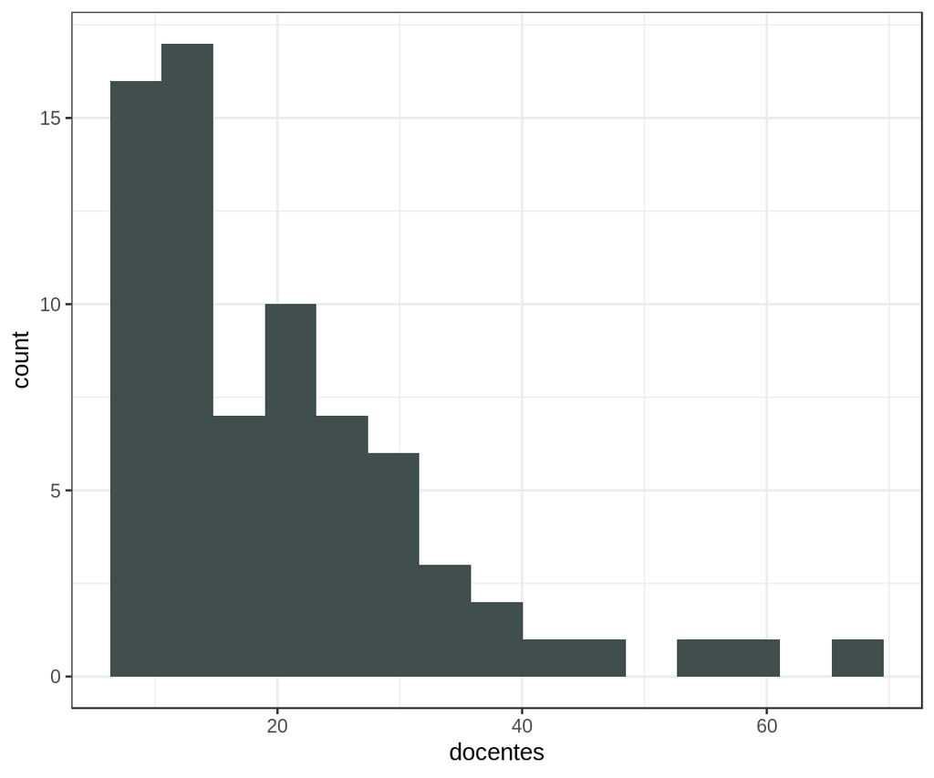

```r
cacc %>%
  ggplot(aes(x = docentes)) +
  geom_histogram(bins = 15, fill = paleta[1])
```

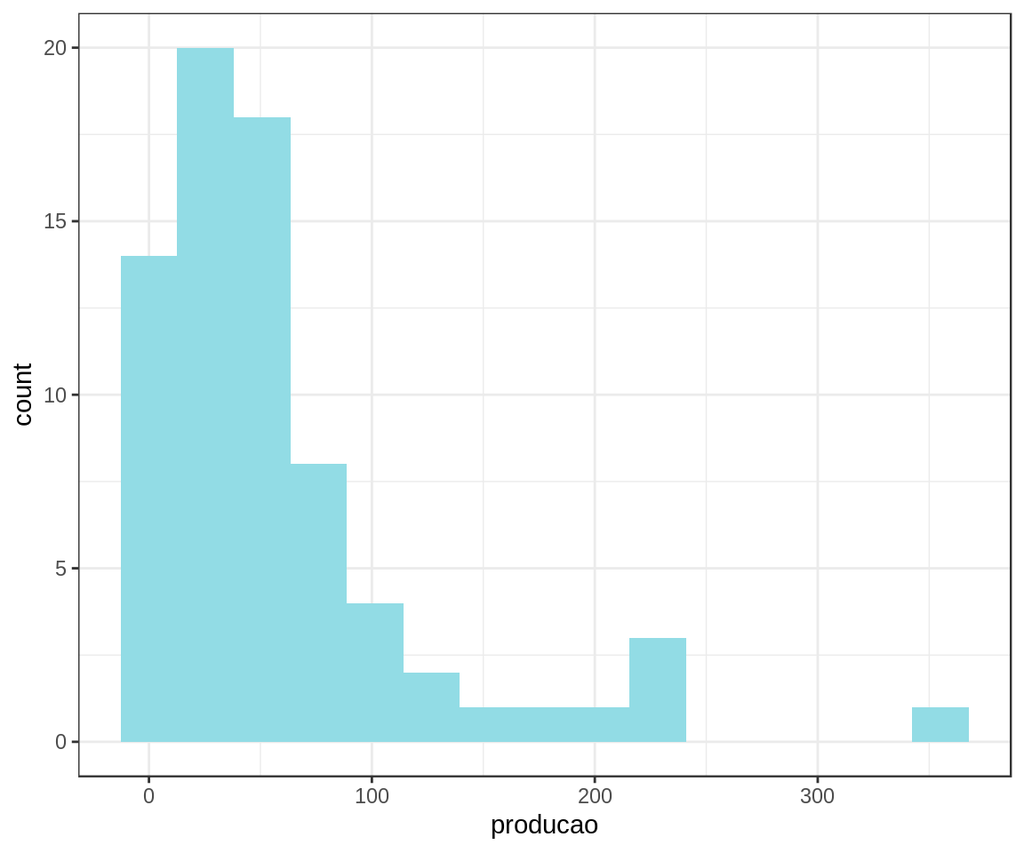

```r
cacc %>%
  ggplot(aes(x = producao)) +
  geom_histogram(bins = 15, fill = paleta[2])
```

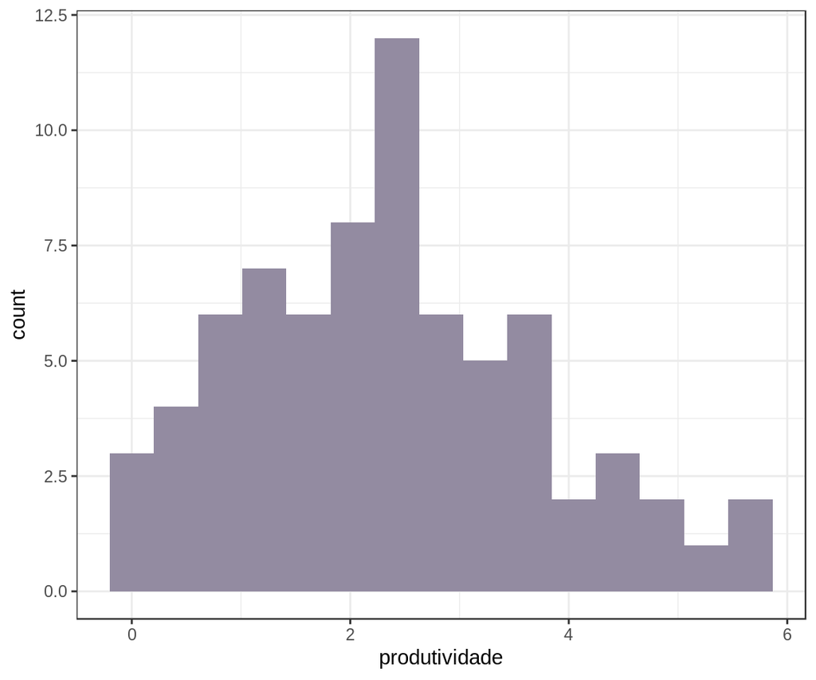

```r
cacc %>%
  ggplot(aes(x = produtividade)) +
  geom_histogram(bins = 15, fill = paleta[3])
```

Se quisermos modelar o efeito do tamanho do programa em termos de docentes (permanentes) na quantidade de artigos publicados, podemos usar regressão.

*Importante*: sempre queremos ver os dados antes de fazermos qualquer modelo ou sumário:

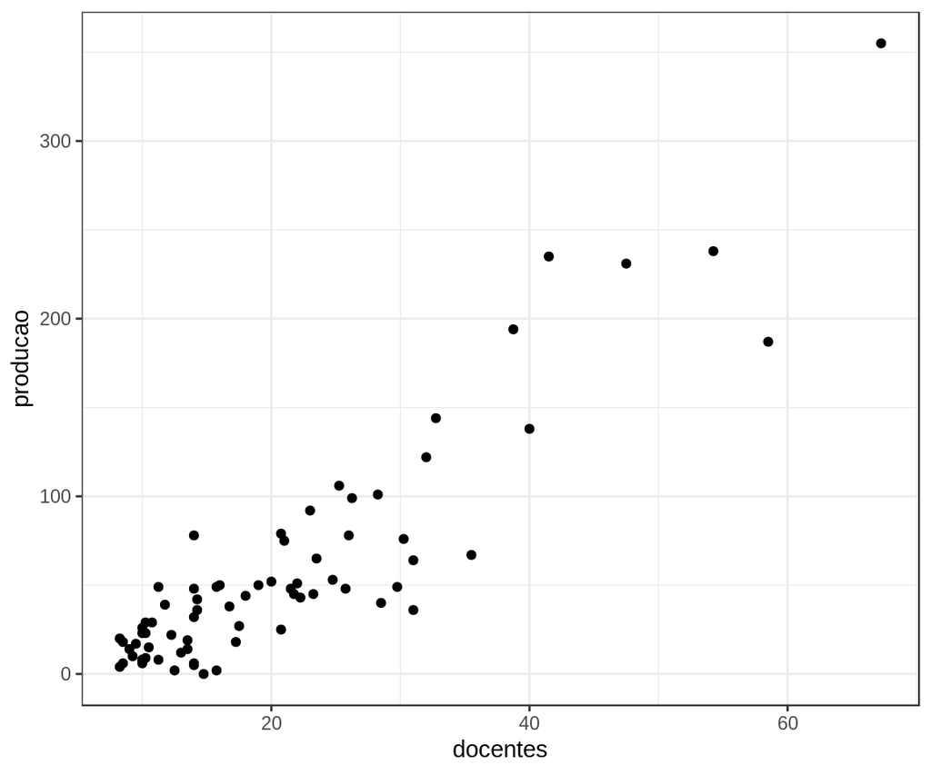

```r
cacc %>%
  ggplot(aes(x = docentes, y = producao)) +
  geom_point()
```

Parece que existe uma relação. Vamos criar um modelo então:

```r
modelo1 = lm(producao ~ docentes, data = cacc)

tidy(modelo1, conf.int = TRUE, conf.level = 0.95)
```

| term | estimate | std.error | statistic | p.value | conf.low | conf.high |
| --- | --- | --- | --- | --- | --- | --- |
| (Intercept) | -41.27309 | 6.5299245 | -6.320607 | 2.014731e-08 | -54.293387 | -28.252788 |
| docentes | 4.81337 | 0.2725331 | 17.661601 | 1.088465e-27 | 4.269955 | 5.356786 |

```r
glance(modelo1)
```

|  | r.squared | adj.r.squared | sigma | statistic | p.value | df | logLik | AIC | BIC | deviance | df.residual |
| --- | --- | --- | --- | --- | --- | --- | --- | --- | --- | --- | --- |
| 1 | 0.8145886 | 0.8119771 | 28.37407 | 311.9322 | 1.088465e-27 | 2 | -346.7883 | 699.5766 | 706.4479 | 57161.22 | 71 |

Para visualizar o modelo:

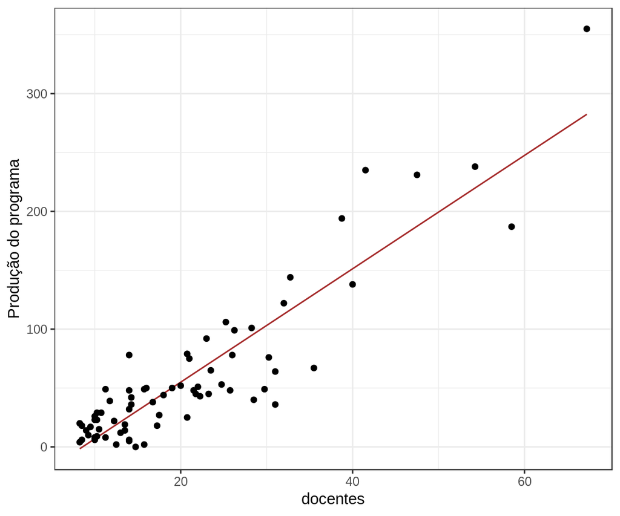

```r
cacc_augmented = cacc %>%
  add_predictions(modelo1)

cacc_augmented %>%
  ggplot(aes(x = docentes)) +
  geom_line(aes(y = pred), colour = "brown") +
  geom_point(aes(y = producao)) +
  labs(y = "Produção do programa")
```

Se considerarmos que temos apenas uma amostra de todos os programas de pós em CC no Brasil, o que podemos inferir a partir desse modelo sobre a relação entre número de docentes permanentes e produção de artigos em programas de pós?

> Regressão foi utilizada para analisar se a proporção de docentes tem uma associação significativa com a produção dos cursos de pós-graduação nos cursos ligados à computação. Os resultados da regressão indicam que um modelo com os 1 preditor no formato produção = 4.81 * docentes - 41.27 explica 81,45% da variância da variável de resposta. Docentes tem uma relação significativa com o erro (b = [4.27; 5.36], IC com 95%). O aumento de 1 unidade de docentes produz uma mudança de 4.81 na produção.

Com isso, podemos compreender que os docentes tem uma relação forte com a produção dos cursos de graduação. Esta relação já é esperada, através da intuição de que mais docentes são capazes de produzir mais trabalhos.

## Mais fatores

```r
modelo2 = lm(producao ~ docentes + mestrados_pprof + doutorados_pprof + tem_doutorado,
             data = cacc_md)

tidy(modelo2, conf.int = TRUE, conf.level = 0.95)
```

| term | estimate | std.error | statistic | p.value | conf.low | conf.high |
| --- | --- | --- | --- | --- | --- | --- |
| (Intercept) | -39.47122811 | 17.7149728 | -2.228128069 | 3.351691e-02 | -75.650029 | -3.292427 |
| docentes | 4.38981679 | 0.5393925 | 8.138446217 | 4.383268e-09 | 3.288230 | 5.491403 |
| mestrados_pprof | 0.03183872 | 3.4855675 | 0.009134443 | 9.927723e-01 | -7.086640 | 7.150317 |
| doutorados_pprof | 16.10750304 | 8.8008817 | 1.830214689 | 7.717000e-02 | -1.866295 | 34.081301 |

```r
glance(modelo2)
```

|  | r.squared | adj.r.squared | sigma | statistic | p.value | df | logLik | AIC | BIC | deviance | df.residual |
| --- | --- | --- | --- | --- | --- | --- | --- | --- | --- | --- | --- |
| 1 | 0.8162424 | 0.7978667 | 34.08472 | 44.41953 | 3.747447e-11 | 4 | -166.097 | 342.194 | 349.8258 | 34853.04 | 30 |

E se considerarmos também o número de alunos?

```r
modelo2 = lm(producao ~ docentes + mestrados + doutorados, data = cacc)

tidy(modelo2, conf.int = TRUE, conf.level = 0.95)
```

| term | estimate | std.error | statistic | p.value | conf.low | conf.high |
| --- | --- | --- | --- | --- | --- | --- |
| (Intercept) | -14.3663077 | 7.45407703 | -1.927309 | 5.805909e-02 | -29.2367845 | 0.5041691 |
| docentes | 3.4997112 | 0.45965441 | 7.613788 | 1.015822e-10 | 2.5827257 | 4.4166967 |
| mestrados | -0.1949515 | 0.08159627 | -2.389221 | 1.962240e-02 | -0.3577316 | -0.0321714 |
| doutorados | 1.0007711 | 0.18309265 | 5.465927 | 6.874998e-07 | 0.6355112 | 1.3660309 |

```r
glance(modelo2)
```

|  | r.squared | adj.r.squared | sigma | statistic | p.value | df | logLik | AIC | BIC | deviance | df.residual |
| --- | --- | --- | --- | --- | --- | --- | --- | --- | --- | --- | --- |
| 1 | 0.8706642 | 0.8650409 | 24.03905 | 154.8316 | 1.416348e-30 | 4 | -333.6422 | 677.2845 | 688.7368 | 39873.45 | 69 |

Visualizar o modelo com muitas variáveis independentes fica mais difícil

```r
para_plotar_modelo = cacc %>%
  data_grid(producao = seq_range(producao, 10), # Crie um vetor de 10 valores no range
            docentes = seq_range(docentes, 4),
            # mestrados = seq_range(mestrados, 3),
            mestrados = median(mestrados),
            doutorados = seq_range(doutorados, 3)) %>%
  add_predictions(modelo2)

glimpse(para_plotar_modelo)
```

```
## Observations: 120
## Variables: 5
## $ producao   <dbl> 0.00000, 0.00000, 0.00000, 0.00000, 0.00000, 0.0000...
## $ docentes   <dbl> 8.25000, 8.25000, 8.25000, 27.91667, 27.91667, 27.9...
## $ mestrados  <int> 58, 58, 58, 58, 58, 58, 58, 58, 58, 58, 58, 58, 58,...
## $ doutorados <dbl> 0, 76, 152, 0, 76, 152, 0, 76, 152, 0, 76, 152, 0, ...
## $ pred       <dbl> 3.199123, 79.257725, 155.316327, 72.026777, 148.085...
```

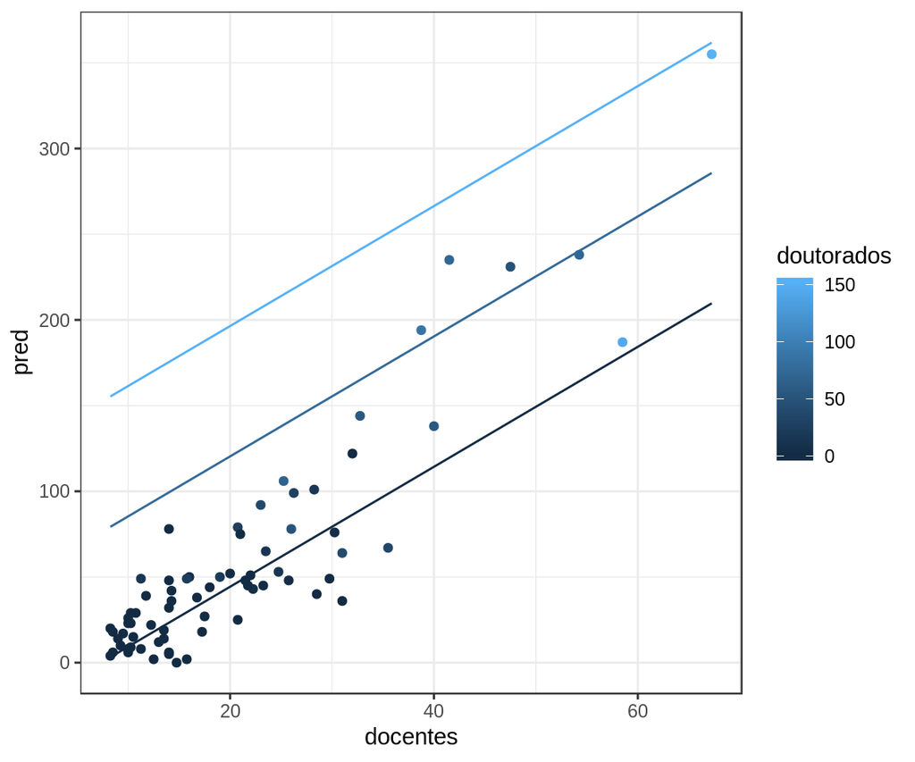

```r
para_plotar_modelo %>%
  ggplot(aes(x = docentes, y = pred)) +
  geom_line(aes(group = doutorados, colour = doutorados)) +
  geom_point(data = cacc, aes(y = producao, colour = doutorados))
```

Considerando agora esses três fatores, o que podemos dizer sobre como cada um deles se relaciona com a produção de um programa de pós em CC? E sobre o modelo? Ele explica mais que o modelo 1?

## Agora produtividade

Diferente de medirmos produção (total produzido), é medirmos produtividade (produzido / utilizado). Abaixo focaremos nessa análise. Para isso crie um modelo que investiga como um conjunto de fatores que você julga que são relevantes se relacionam com a produtividade dos programas. Crie um modelo que avalie como *pelo menos 3 fatores* se relacionam com a produtividade de um programa. Pode reutilizar fatores que já definimos e analizamos para produção. Mas cuidado para não incluir fatores que sejam função linear de outros já incluídos (ex: incluir A, B e um tercero C=A+B)

Produza abaixo o modelo e um texto que comente (i) o modelo, tal como os que fizemos antes, e (ii) as implicações - o que aprendemos sobre como funcionam programas de pós no brasil?.

```r
library(GGally)
```

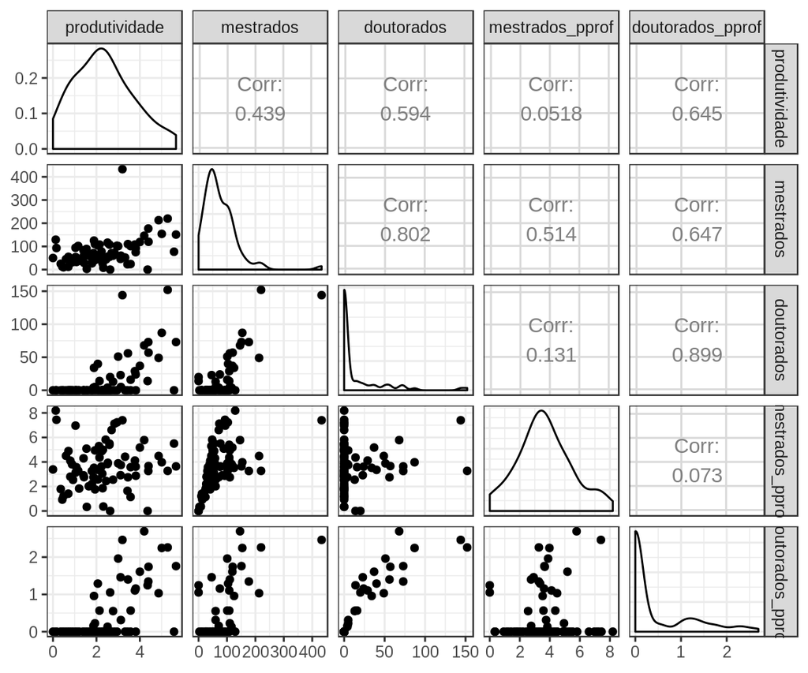

```r
ggpairs(cacc %>% select(produtividade, mestrados, doutorados, mestrados_pprof, doutorados_pprof, ))
```

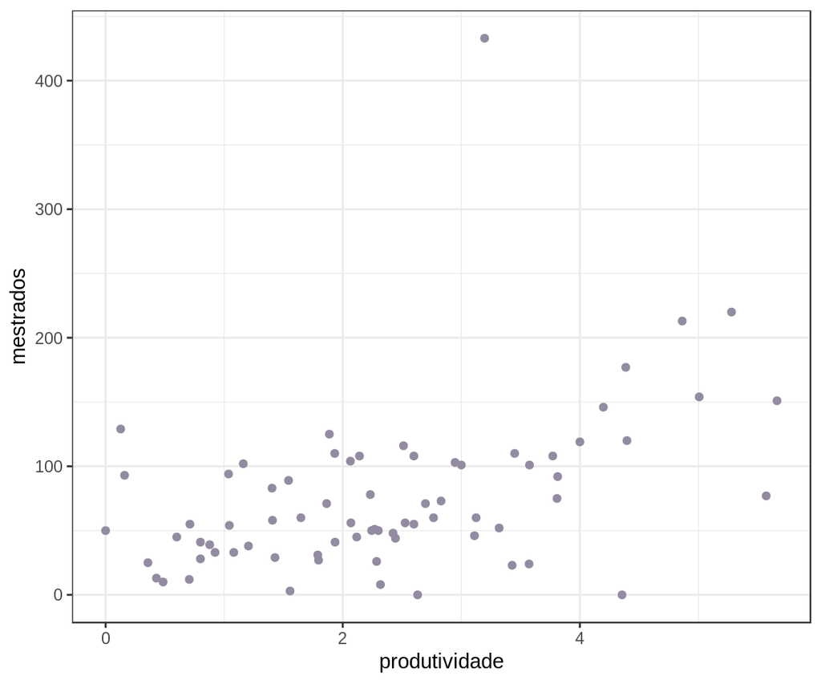

```r
cacc %>%
  ggplot(aes(x = produtividade, y = mestrados)) +
  geom_point(color=paleta[3])
```